# 연도별 OTT 시청인구의 비율 비교

김선우

2022-11-25

# 주제: 연도별 OTT 시청인구 비율의 비교

## 0. 출처

- https://stat.kisdi.re.kr/kor/tblInfo/TblInfoList2.html?vw_cd=MT_ETITLE&siteGb=SITE001
- 미디어통계포털 / KISDISTAT - 최근 3개월 OTT서비스 이용 경험여부
- 미디어통계포털 / KISDISTAT - OTT유료결제_이용여부

## 1. 데이터 파일 불러오기

```r
mydata <- read.csv('C:/Kimsunwoo/teamprojectdata/ksw/ott.csv', header=T)
View(mydata)
```

## 2. 패키지 준비

```r
library(ggplot2)
library(dplyr)
library(tidyr)
library(readxl)
library(reshape2)
library(gridExtra)
```

## 3. 전처리

### (1) 컬럼 이름 변경

```r
### 컬럼에 무엇이 이름으로 되어 있는지 몇개를 불러와 확인
mydata[mydata$구분별.2.=='남',]
```

```
##   구분별.1. 구분별.2.      X2019  X2019.1  X2019.2 X2020  X2020.1  X2020.2
## 3      성별        남 5401.05458 43.98317 56.01683  5146 75.24439 24.75561
##    X2021 X2021.1 X2021.2
## 3 5061.2    84.6    15.4
```

```r
mydata[mydata$구분별.2.=='여',]
```

```
##   구분별.1. 구분별.2.      X2019  X2019.1  X2019.2 X2020  X2020.1  X2020.2
## 4      성별        여 5462.94542 38.11403 61.88597  5156 69.08849 30.91151
##    X2021 X2021.1 X2021.2
## 4 5092.8    78.7    21.3
```

```r
### 원래 데이터를 복사해서 새 데이터 만들기
mydata1 <- mydata
names(mydata1)
```

```
##  [1] "구분별.1." "구분별.2." "X2019"     "X2019.1"   "X2019.2"   "X2020"
##  [7] "X2020.1"   "X2020.2"   "X2021"     "X2021.1"   "X2021.2"
```

```r
### 각 컬럼을 카테고리와 연도별로 나눠서 새로 이름을 지음

mydata1<-rename(mydata1, cat1=구분별.1., cat2=구분별.2., 총인구.2019=X2019, 시청경험_있음.2019=X2019.1, 시청경험_없음.2019=X2019.2, 총인구.2020=X2020, 시청경험_있음.2020=X2020.1, 시청경험_없음.2020=X2020.2, 총인구.2021=X2021, 시청경험_있음.2021=X2021.1, 시청경험_없음.2021=X2021.2)
mydata1 <- mydata1[-1,]

summary(mydata1)
```

```
##      cat1               cat2           총인구.2019        시청경험_있음.2019
##  Length:86          Length:86          Length:86          Length:86
##  Class :character   Class :character   Class :character   Class :character
##  Mode  :character   Mode  :character   Mode  :character   Mode  :character
##  시청경험_없음.2019 총인구.2020        시청경험_있음.2020 시청경험_없음.2020
##  Length:86          Length:86          Length:86          Length:86
##  Class :character   Class :character   Class :character   Class :character
##  Mode  :character   Mode  :character   Mode  :character   Mode  :character
##  총인구.2021        시청경험_있음.2021 시청경험_없음.2021
##  Length:86          Length:86          Length:86
##  Class :character   Class :character   Class :character
##  Mode  :character   Mode  :character   Mode  :character
```

### (2) 변수명 처리

```r
### 각 조건들을 같은 범주 내에 있는 것들끼리 묶어서 하나의 변수로 만들기

sex <- subset(mydata1, cat1 == '성별')
age <- subset(mydata1, cat1 == '연령')
income <- subset(mydata1, cat1 == '월평균소득')
school <- subset(mydata1, cat1 == '학력1')
region <- subset(mydata1, cat1 == '지역')
region.1 <- subset(mydata1, cat1 == '지역구분2')
job.wide <- subset(mydata1, cat1 == '종사상지위')
job.narrow <- subset(mydata1, cat1 == '상세직업')
house <- subset(mydata1, cat1 == '주택형태')
family.1 <- subset(mydata1, cat1 == '가족구성')
family.2 <- subset(mydata1, cat1 == '가구원수')
family.3 <- subset(mydata1, cat1 == '가구주와의관계')
```

## 4. EDA

### (1) 남자와 여자 년도별 OTT시청 비율 증가량 비교

#### 1) Preprocessing

```r
### 남자와 여자 각각 변수 지정

man <- subset(mydata1, cat2 == '남')
woman <- subset(mydata1, cat2 == '여')

### 남자와 여자를 각각 long 타입으로 변경

man1 <- man %>% select(시청경험_있음.2019, 시청경험_있음.2020, 시청경험_있음.2021)
man1
```

```
##   시청경험_있음.2019 시청경험_있음.2020 시청경험_있음.2021
## 3           43.98317           75.24439               84.6
```

```r
woman1 <- woman %>% select(시청경험_있음.2019, 시청경험_있음.2020, 시청경험_있음.2021)
woman1
```

```
##   시청경험_있음.2019 시청경험_있음.2020 시청경험_있음.2021
## 4           38.11403           69.08849               78.7
```

```r
long.man <- man1 %>% gather(key = years, value = pop)
long.man
```

```
##                years      pop
## 1 시청경험_있음.2019 43.98317
## 2 시청경험_있음.2020 75.24439
## 3 시청경험_있음.2021     84.6
```

```r
long.woman <- woman1 %>% gather(key = years, value = pop)
long.woman
```

```
##                years      pop
## 1 시청경험_있음.2019 38.11403
## 2 시청경험_있음.2020 69.08849
## 3 시청경험_있음.2021     78.7
```

```r
long.man$pop
```

```
## [1] "43.98317" "75.24439" "84.6"
```

```r
long.woman$pop
```

```
## [1] "38.11403" "69.08849" "78.7"
```

#### 2) 시각화

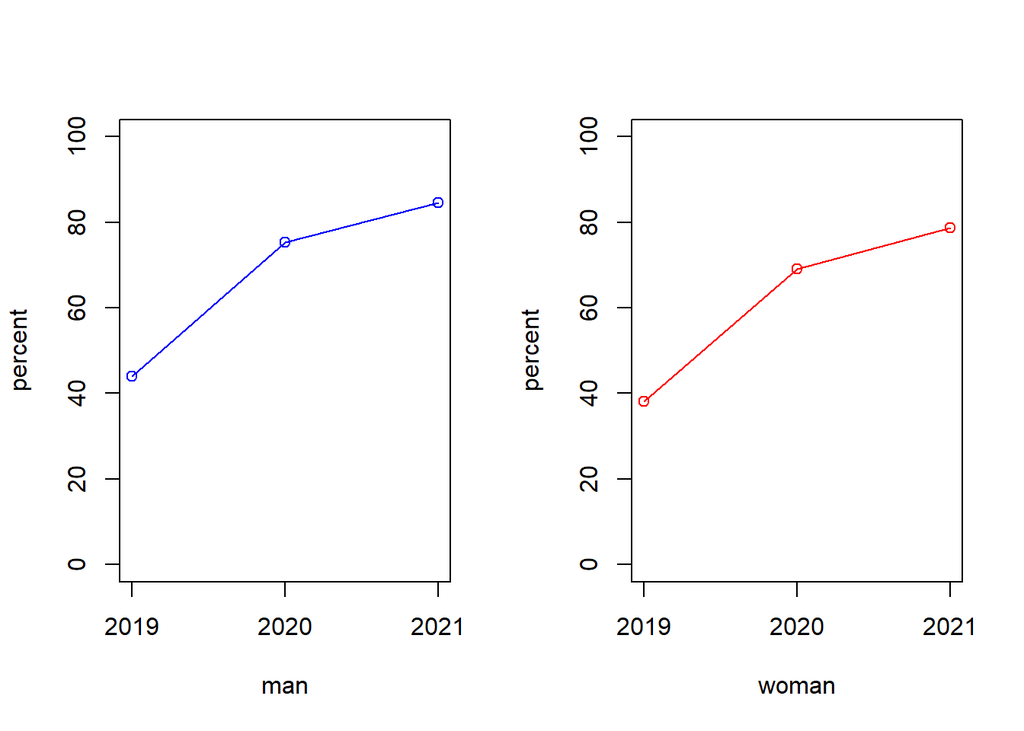

```r
### plot() 함수를 사용해 그래프로 나타내기
par(mfrow=c(1,2)) # 한번에 2개의 그래프를 표시
plot(long.man$pop, type='o',xlab = 'man', ylab='percent',xlim=c(1,3), ylim=c(0,100),xaxt = "n", col='blue') # 남자 그래프 : 파란색
axis(1, at=1:3, labels = c('2019', '2020', '2021')) # 눈금 이름 연도로 바꿔주기

plot(long.woman$pop, type='o',xlab = 'woman',ylab='percent',xlim=c(1,3), ylim=c(0,100),xaxt = "n",col='red') # 여자 그래프 : 빨간색
axis(1, at=1:3, labels = c('2019', '2020', '2021')) # 눈금 이름 색 지정해주기
```

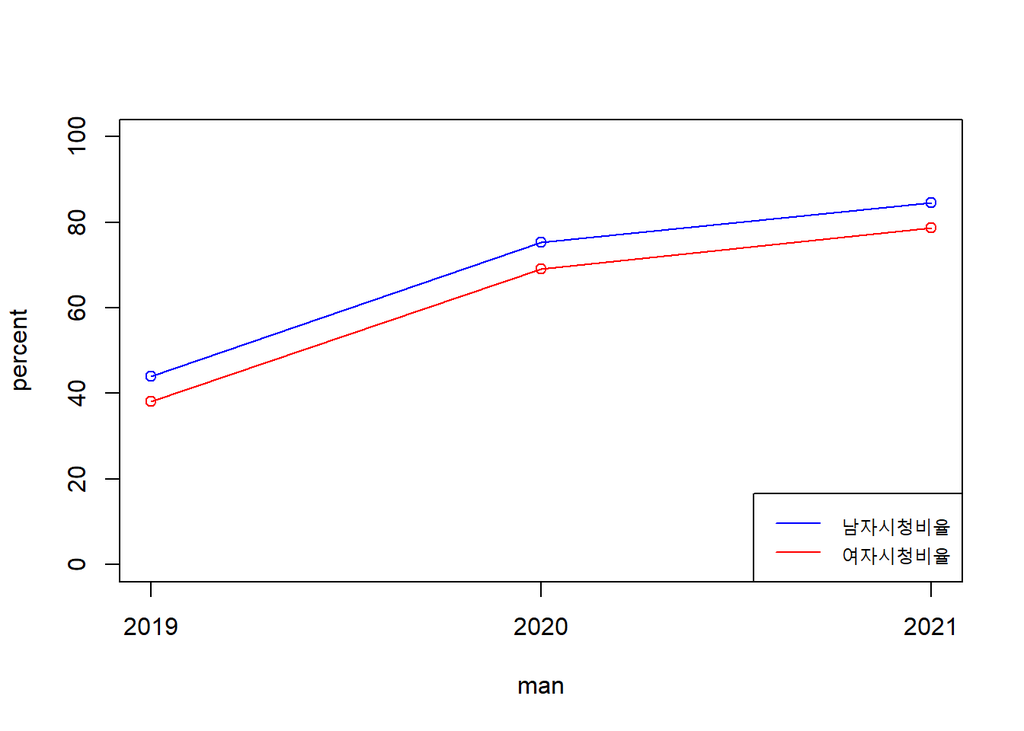

```r
### 그래프 하나에 나타내주기

par(mfrow=c(1,1))
plot(long.man$pop, type='o',xlab = 'man', ylab='percent',xlim=c(1,3), ylim=c(0,100),xaxt = "n", col='blue',lty=1)
lines(long.woman$pop, type='o',xlab = 'woman',ylab='percent',xlim=c(1,3), ylim=c(0,100),xaxt = "n",col='red',lty=1)
axis(1, at=1:3, labels = c('2019', '2020', '2021'))

legend("bottomright", c("남자시청비율", "여자시청비율"),
       col = c('blue','red'),lty=1)
```

#### 3) 결론

- 코로나가 시작된 2019년 이후로 남녀 모두 OTT시청 비율이 급격히 늘었다.

### (2) 나이대에 따라 연도별 OTT시청 비율 증가량 비교 및 주 시청자의 나이대 추론

#### 1) 전처리

```r
### 위에서 나눈 범주들 중 나이에 관한 age를 사용
age
```

```
##    cat1       cat2 총인구.2019 시청경험_있음.2019 시청경험_없음.2019
## 5  연령 만10대미만     346.471           23.26517           76.73483
## 6  연령  만10-19세  1036.24078           48.39652           51.60348
## 7  연령  만20-29세   1564.4129           65.35749           34.64251
## 8  연령  만30-39세   1578.3249           62.00919           37.99081
## 9  연령  만40-49세  1838.33348           47.20841           52.79159
## 10 연령  만50-59세  1924.86655            35.5234            64.4766
## 11 연령  만60-69세  1383.76062           19.77864           80.22136
## 12 연령 만70세이상  1191.58978            4.12138           95.87862
##    총인구.2020 시청경험_있음.2020 시청경험_없음.2020 총인구.2021
## 5          258           67.07017           32.92983       226.1
## 6          984             83.827             16.173       962.7
## 7         1440           95.66889            4.33111      1411.4
## 8         1509           94.10247            5.89753      1441.2
## 9         1745            84.8776            15.1224        1694
## 10        1827           75.15522           24.84478        1788
## 11        1377           48.34963           51.65037      1453.5
## 12        1162           10.25231           89.74769      1177.2
##    시청경험_있음.2021 시청경험_없음.2021
## 5                77.2               22.8
## 6                91.4                8.6
## 7                97.9                2.1
## 8                96.5                3.5
## 9                93.6                6.4
## 10               88.4               11.6
## 11               70.6               29.4
## 12               23.4               76.6
```

```r
age1 <- age %>% select(cat2, 시청경험_있음.2019, 시청경험_있음.2020, 시청경험_있음.2021)
View(age1) # 새로 나이에 관한 범주의 복사본 만들어주기

### 각 나이대별로 새로운 범주 만들어주기

age10d <- subset(age1, cat2 == '만10대미만')
age10to19 <- subset(age1, cat2 == '만10-19세')
age20to29 <- subset(age1, cat2 == '만20-29세')
age30to39 <- subset(age1, cat2 == '만30-39세')
age40to49 <- subset(age1, cat2 == '만40-49세')
age50to59 <- subset(age1, cat2 == '만50-59세')
age60to69 <- subset(age1, cat2 == '만60-69세')
age70u <- subset(age1, cat2 == '만70세이상')
```

```r
### 나이대별 범주 전부 long 형태로 바꿔주고 필요없는 첫째 행 없애주기
long.age10d <- age10d %>% gather(key = years, value = pop)
long.age10d <-long.age10d[-1,]
long.age10to19 <- age10to19 %>% gather(key = years, value = pop)
long.age10to19 <- long.age10to19[-1,]
long.age20to29 <- age20to29 %>% gather(key = years, value = pop)
long.age20to29 <- long.age20to29[-1,]
long.age30to39 <- age30to39 %>% gather(key = years, value = pop)
long.age30to39 <- long.age30to39[-1,]
long.age40to49 <- age40to49 %>% gather(key = years, value = pop)
long.age40to49 <- long.age40to49[-1,]
long.age50to59 <- age50to59 %>% gather(key = years, value = pop)
long.age50to59 <- long.age50to59[-1,]
long.age60to69 <- age60to69 %>% gather(key = years, value = pop)
long.age60to69 <- long.age60to69[-1,]
long.age70u <- age70u %>% gather(key = years, value = pop)
long.age70u <- long.age70u[-1,]
```

#### 2) 시각화

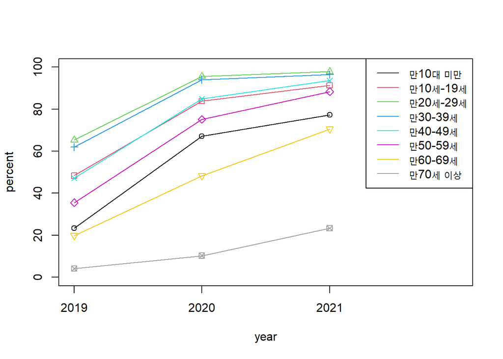

```r
par(mfrow=c(1,1)) # 하나의 그래프만 나타내기
plot(long.age10d$pop,type='o',xlim=c(1,4), ylim=c(0,100),xaxt = "n",xlab = 'year', ylab='percent',col=1) # 기본 그래프 10세미만으로 설정
axis(1, at=1:3, labels = c('2019', '2020', '2021')) # 눈금 이름 연도로 바꿔주기
lines(long.age10to19$pop,type='o',col=2,pch=0) # 겹
lines(long.age20to29$pop,type='o',col=3,pch=2) # 쳐
lines(long.age30to39$pop,type='o',col=4,pch=3) # 서
lines(long.age40to49$pop,type='o',col=5,pch=4) # 그
lines(long.age50to59$pop,type='o',col=6,pch=5) # 려
lines(long.age60to69$pop,type='o',col=7,pch=6) # 주
lines(long.age70u$pop,type='o',col=8,pch=7)    # 기


### 그래프 우측 상단에 범례 만들어주기
legend("topright", c("만10대 미만", "만10세-19세", "만20세-29세", "만30-39세", "만40-49세", "만50-59세", "만60-69세", "만70세 이상"),
       col = c(1,2,3,4,5,6,7,8),lty=1)
```

### (3) 가구원 수에 따라 OTT를 구독하는 비율이 차이가 날 것인가?

- OTT서비스는 한 사람만 구독해도 4명까지 공유 가능한 시스템 덕에 가구원 수가 많을수록 구독 비율이 적어질 것이라 예상.

#### 1) 데이터 파일 불러오기

```r
### 이전 데이터파일과는 다른 데이터를 사용하니 새로 파일 불러와주기
mydata2 <- read.csv('C:/Kimsunwoo/teamprojectdata/ksw/OTT유료결제_이용여부.csv', header=T)
View(mydata2)
```

#### 2) 전처리

```r
### 새로운 복사 데이터 만들기
moneydata <- mydata2
names(moneydata)
```

```
## [1] "구분별.1." "구분별.2." "X2019"     "X2019.1"   "X2019.2"   "X2020"
## [7] "X2020.1"   "X2020.2"
```

```r
### 각 조건들을 같은 범주 내에 있는 것들끼리 묶어서 하나의 변수로 만들기
moneydata<-rename(moneydata, cat1=구분별.1., cat2=구분별.2., 총인구.2019=X2019, 결제경험_있음.2019=X2019.1, 결제경험_없음.2019=X2019.2, 총인구.2020=X2020, 결제경험_있음.2020=X2020.1, 결제경험_없음.2020=X2020.2)
moneydata <- moneydata[-1,]

View(moneydata)
```

#### 3) 필요한 데이터-가구원 수 뽑아오기

```r
### 변수들 중 필요한 변수를 골라 새롭게 데이터를 지정
family.money <- subset(moneydata, cat1 == '가구원수1')
family.money
```

```
##         cat1        cat2 총인구.2019 결제경험_있음.2019 결제경험_없음.2019
## 75 가구원수1     1인가구    441.3141            14.2468            85.7532
## 76 가구원수1     2인가구   919.47288            9.53128           90.46872
## 77 가구원수1 3인이상가구  3096.91704           10.18089           89.81911
##    총인구.2020 결제경험_있음.2020 결제경험_없음.2020
## 75         822           26.81698           73.18302
## 76        1586            14.1709            85.8291
## 77        5027           12.38408           87.61592
```

```r
family.money1 <- family.money %>% select(cat2, 결제경험_있음.2019, 결제경험_있음.2020)
family.money1
```

```
##           cat2 결제경험_있음.2019 결제경험_있음.2020
## 75     1인가구            14.2468           26.81698
## 76     2인가구            9.53128            14.1709
## 77 3인이상가구           10.18089           12.38408
```

```r
### 고른 데이터를 long 형태로 변경해주기
people1 <- subset(family.money1, cat2 == '1인가구')
people2 <- subset(family.money1, cat2 == '2인가구')
people3 <- subset(family.money1, cat2 == '3인이상가구')

long.people1 <- people1 %>% gather(key = years, value = pop)
long.people2 <- people2 %>% gather(key = years, value = pop)
long.people3 <- people3 %>% gather(key = years, value = pop)
```

#### 4) 시각화

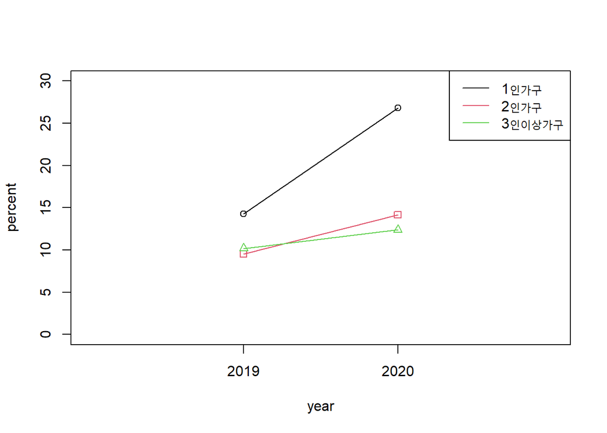

```r
par(mfrow=c(1,1)) # 하나의 그래프만 나타내기
plot(long.people1$pop,type='o',xlim=c(1,4), ylim=c(0,30),xaxt = "n",xlab = 'year', ylab='percent',col=1)
axis(1, at=2:3, labels = c('2019', '2020')) # 눈금 년도로 이름지어주기
lines(long.people2$pop,type='o',col=2,pch=0)
lines(long.people3$pop,type='o',col=3,pch=2) # 그래프 전부 겹쳐주기

legend("topright", c("1인가구", "2인가구", "3인이상가구"),
       col = c(1,2,3),lty=1) # 범례 만들어주기
```

### (4) 소득수준에 따라 OTT를 구독하는 비율이 차이가 날 것인가?

- 예상 : 소득 수준이 낮을수록 구독 비율이 낮을 것이다.

#### 1) 전처리

```r
### 위에서 분류한 income을 가지고 데이터 분석
income.y <-  income %>% select(cat2, 시청경험_있음.2019, 시청경험_있음.2020, 시청경험_있음.2021)
View(income.y)
```

```r
###각 소득별로 새로운 범주 만들어주기

income1 <- subset(income.y, cat2 == '소득없음')
income2 <- subset(income.y, cat2 == '50만원미만')
income3 <- subset(income.y, cat2 == '50-100만원미만')
income4 <- subset(income.y, cat2 == '100-200만원미만')
income5 <- subset(income.y, cat2 == '200-300만원미만')
income6 <- subset(income.y, cat2 == '300-400만원미만')
income7 <- subset(income.y, cat2 == '400-500만원미만')
income8 <- subset(income.y, cat2 == '500만원이상')
```

```r
### long 형태로 바꿔주기
long.income1 <- income1 %>% gather(key = years, value = pop)
long.income2 <- income2 %>% gather(key = years, value = pop)
long.income3 <- income3 %>% gather(key = years, value = pop)
long.income4 <- income4 %>% gather(key = years, value = pop)
long.income5 <- income5 %>% gather(key = years, value = pop)
long.income6 <- income6 %>% gather(key = years, value = pop)
long.income7 <- income7 %>% gather(key = years, value = pop)
long.income8 <- income8 %>% gather(key = years, value = pop)
```

#### 2) 데이터 시각화

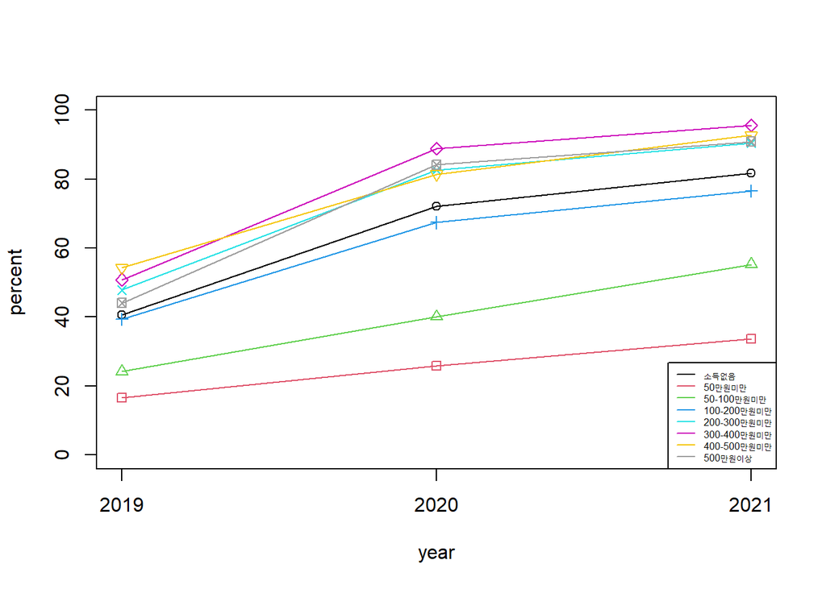

```r
###그래프 겹쳐서 그려주기
par(mfrow=c(1,1))
plot(long.income1$pop,type='o',xlim=c(2,4), ylim=c(0,100),xaxt = "n",xlab = 'year', ylab='percent',col=1)
axis(1, at=2:4, labels = c('2019', '2020', '2021'))
lines(long.income2$pop,type='o',col=2,pch=0)
lines(long.income3$pop,type='o',col=3,pch=2)
lines(long.income4$pop,type='o',col=4,pch=3)
lines(long.income5$pop,type='o',col=5,pch=4)
lines(long.income6$pop,type='o',col=6,pch=5)
lines(long.income7$pop,type='o',col=7,pch=6)
lines(long.income8$pop,type='o',col=8,pch=7)

#범례 추가
legend("bottomright", c("소득없음", "50만원미만", "50-100만원미만", "100-200만원미만", "200-300만원미만", "300-400만원미만", "400-500만원미만", "500만원이상"),
       col = c(1,2,3,4,5,6,7,8),lty=1, cex=0.5)
```

### (6) 평균이용시간과 평균이용빈도는 나이대에 따라 관련이 있을 것인가?

#### 1) 데이터 파일 불러오기

```r
mydata3 <- read.csv('C:/Kimsunwoo/teamprojectdata/ksw/(미디어 통계포털 - KISDI STAT)OTT서비스_이용시간.csv', header=T)

mydata4 <- read.csv('C:/Kimsunwoo/teamprojectdata/ksw/(미디어 통계포털 - KISDI STAT)OTT서비스_이용빈도.csv', header=T)
```

#### 2) 평균 이용시간 전처리

```r
# 파일 복사 데이터 만들기
time <- mydata3

# 컬럼 이름 재조정 및 필요없는 행 지우기
time <- rename(time, cat1=구분별.1., cat2=구분별.2., 총인구.2020=X2020, '5m-Under'=X2020.1, '5m-10m'=X2020.2, '10m-30m'=X2020.3, '30m-1h'=X2020.4, '1h-2h'=X2020.5, '2h-Up'=X2020.6)
time <- time[-1,]

#필요한 연령 카테고리만 빼오기
ages <- subset(time, cat1 == '연령')

# 각 이용시간별 새로운 범주 만들어주기
ages.2020 <- ages %>% select(cat2 ,'5m-Under', '5m-10m', '10m-30m', '30m-1h', '1h-2h', '2h-Up')

#필요한 나이대(만10세-39세)만 골라오기 및 범주화
X <- ages.2020[(2:4),]

ages1 <- subset(ages.2020, cat2 == '만10-19세')
ages1 <- ages1 %>% select('5m-Under', '5m-10m', '10m-30m', '30m-1h', '1h-2h', '2h-Up')
ages2 <- subset(ages.2020, cat2 == '만20-29세')
ages2 <- ages2 %>% select('5m-Under', '5m-10m', '10m-30m', '30m-1h', '1h-2h', '2h-Up')
ages3 <- subset(ages.2020, cat2 == '만30-39세')
ages3 <- ages3 %>% select('5m-Under', '5m-10m', '10m-30m', '30m-1h', '1h-2h', '2h-Up')

# long형으로 바꿔주기
long.ages1 <- ages1 %>% gather(key = times, value = percent)
long.ages2 <- ages2 %>% gather(key = times, value = percent)
long.ages3 <- ages3 %>% gather(key = times, value = percent)
```

#### 3) 평균 이용시간 시각화

[figure not shown]

```r
# 그래프 중 많은 비율 두 개에 검은색 넣어주기
color <- c('5m-Under'='#999999', '5m-10m'='#999999', '10m-30m'='#000000', '30m-1h'='#000000', '1h-2h'='#999999', '2h-Up'='#999999')

color1 <- c('5m-Under'='#999999', '5m-10m'='#999999', '10m-30m'='#999999', '30m-1h'='#000000', '1h-2h'='#000000', '2h-Up'='#999999')

#막대 그래프로 각각 비율 나타내주기, x축 눈금 이름 90도로 조정, 배경 하얗게
a <- ggplot(long.ages1, aes(times, percent)) + xlab("만10-19세") + geom_col(fill=color)+ scale_fill_manual(values=color) +
  theme(axis.text.x=element_text(angle=90, hjust=1)) +
  scale_x_discrete(limits = c('5m-Under', '5m-10m', '10m-30m', '30m-1h', '1h-2h', '2h-Up')) + theme_bw()

b <- ggplot(long.ages2, aes(times, percent))+ xlab("만20-29세") + geom_col(fill=color1)+
  scale_fill_manual(values=color)+
  theme(axis.text.x=element_text(angle=90, hjust=1))+
  scale_x_discrete(limits = c('5m-Under', '5m-10m', '10m-30m', '30m-1h', '1h-2h', '2h-Up'))+ theme_bw()

c <- ggplot(long.ages3, aes(times, percent)) + xlab("만30-39세") + geom_col(fill=color)+
  scale_fill_manual(values=color)+
  theme(axis.text.x=element_text(angle=90, hjust=1))+
  scale_x_discrete(limits = c('5m-Under', '5m-10m', '10m-30m', '30m-1h', '1h-2h', '2h-Up'))+ theme_bw()


#묶어서 한 화면에 나타내기
grid.arrange(a,b,c, nrow=2, ncol=2)
```

#### 4) 빈도수 전처리

```r
# 파일 복사 데이터 만들기
many <- mydata4

# 컬럼 이름 재조정 및 필요없는 행 지우기
many <- rename(many,cat1=구분별.1., cat2=구분별.2., population=X2020, 'manytimes.day'=X2020.1, 'one.day'=X2020.2, 'week.5-7'=X2020.3, 'week.3-4'=X2020.4, 'week1-2'=X2020.5, 'month.1-3'=X2020.6,'month.U1'=X2020.7, 'year.1'=X2020.8)
many <- many[-1,]

# 필요한 연령 카테고리만 빼오기

m.ages <- subset(many, cat1 == '연령')

# 각 빈도수 별 새로운 범주 만들어주기
m.ages.2020 <- m.ages %>% select(cat2 ,'manytimes.day', 'one.day', 'week.5-7', 'week.3-4', 'week1-2', 'month.1-3','month.U1', 'year.1')

#필요한 나이대(만10세-39세)만 골라오기 및 범주화
Y <- m.ages.2020[(2:4),]

m.ages1 <- subset(m.ages.2020, cat2 == '만10-19세')
m.ages1 <- m.ages1 %>% select('manytimes.day', 'one.day', 'week.5-7', 'week.3-4', 'week1-2', 'month.1-3','month.U1', 'year.1')
m.ages2 <- subset(m.ages.2020, cat2 == '만20-29세')
m.ages2 <- m.ages1 %>% select('manytimes.day', 'one.day', 'week.5-7', 'week.3-4', 'week1-2', 'month.1-3','month.U1', 'year.1')
m.ages3 <- subset(m.ages.2020, cat2 == '만30-39세')
m.ages3 <- m.ages1 %>% select('manytimes.day', 'one.day', 'week.5-7', 'week.3-4', 'week1-2', 'month.1-3','month.U1', 'year.1')

# long형으로 바꿔주기
long.m.ages1 <- m.ages1 %>% gather(key = times, value = percent)
long.m.ages2 <- m.ages2 %>% gather(key = times, value = percent)
long.m.ages3 <- m.ages3 %>% gather(key = times, value = percent)
```

#### 5) 빈도수 시각화

[figure not shown]

```r
# 그래프 중 많은 비율 두 개에 검은색 넣어주기
color2 <- c('manytimes.day'='#000000', 'one.day'='#000000', 'week.5-7'='#999999', 'week.3-4'='#999999', 'week1-2'='#999999', 'month.1-3'='#999999','month.U1'='#999999', 'year.1'='#999999')

#막대 그래프로 각각 비율 나타내주기, x축 눈금 이름 90도로 조정, 배경 하얗게
A <- ggplot(long.m.ages1, aes(times, percent)) + xlab("만10-19세") + geom_col(fill=color2)+ scale_fill_manual(values=color)+
  theme(axis.text.x=element_text(angle=90, hjust=1)) +
  scale_x_discrete(limits = c('manytimes.day', 'one.day', 'week.5-7', 'week.3-4', 'week1-2', 'month.1-3','month.U1', 'year.1'))
B <- ggplot(long.m.ages2, aes(times, percent)) + xlab("만20-29세") + geom_col(fill=color2)+ scale_fill_manual(values=color)+
  theme(axis.text.x=element_text(angle=90, hjust=1)) +
  scale_x_discrete(limits = c('manytimes.day', 'one.day', 'week.5-7', 'week.3-4', 'week1-2', 'month.1-3','month.U1', 'year.1'))
C <- ggplot(long.m.ages3, aes(times, percent)) + xlab("만30-39세") + geom_col(fill=color2)+ scale_fill_manual(values=color)+
  theme(axis.text.x=element_text(angle=90, hjust=1)) +
  scale_x_discrete(limits = c('manytimes.day', 'one.day', 'week.5-7', 'week.3-4', 'week1-2', 'month.1-3','month.U1', 'year.1'))

#묶어서 한 화면에 나타내기
grid.arrange(A,B,C, nrow=2, ncol=2)
```